# Chapter 2 (ctd): Data and Sampling Distributions

Dr. Rajitha M. Silva

# 1. Introduction to the Normal Distribution

The **normal distribution**, or Gaussian distribution, is foundational in statistics and data science. Many natural processes (like measurement errors, average scores) follow it. In sports analytics, normal distributions help model and interpret performance consistency.

# 2. Key Properties of the Normal Distribution

- Symmetric, bell-shaped curve.
- Defined by mean $\mu$ and standard deviation $\sigma$.
- Follows the **Empirical Rule**:
- Approximately 68% of values lie within $\pm 1\sigma$ of the mean.
- Approximately 95% of values lie within $\pm 2\sigma$ of the mean.
- Approximately 99.7% of values lie within $\pm 3\sigma$ of the mean.

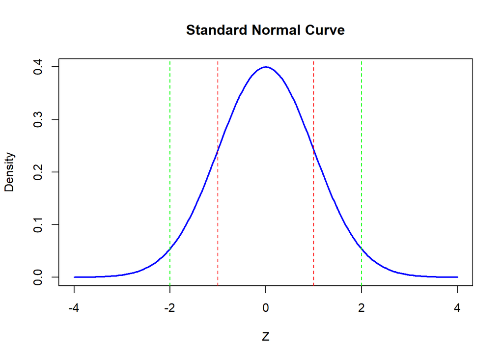

```r
x <- seq(-4, 4, length = 200)
y <- dnorm(x)
plot(x, y, type = "l", lwd = 2, col = "blue", main = "Standard Normal Curve", xlab = "Z", ylab = "Density")
abline(v = c(-1, 1), col = "red", lty = 2)
abline(v = c(-2, 2), col = "green", lty = 2)
```

# 3. Standardization and Z-Scores

We can standardize any value using:

$$z = \frac{x - \mu}{\sigma}$$

This enables comparison across different units or scales.

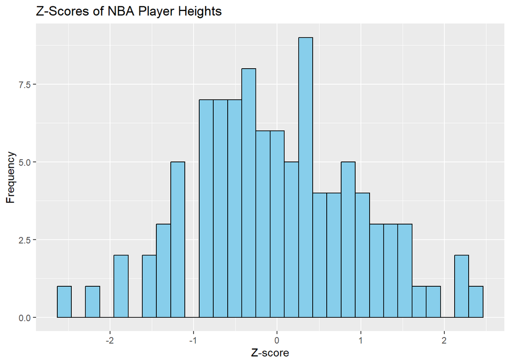

```r
set.seed(123)
nba_heights <- rnorm(100, mean = 200, sd = 10)
z_scores <- scale(nba_heights)

ggplot(data.frame(z_scores), aes(x = z_scores)) +
  geom_histogram(bins = 30, fill = "skyblue", color = "black") +
  ggtitle("Z-Scores of NBA Player Heights") +
  xlab("Z-score") + ylab("Frequency")
```

# 4. Standard Normal Distribution

The standard normal distribution, also known as the z-distribution, is a special case of the normal distribution where the mean is 0 and the standard deviation is 1. It is used as a reference to standardize any normal distribution by converting individual data points into z-scores, which represent how many standard deviations a value is from the mean. This transformation facilitates comparison across datasets. **However, standardizing data (e.g., converting to z-scores) does not make the data normally distributed; it only aligns the scale for comparative purposes.** The normal distribution is often referred to as the Gaussian distribution, named after Carl Friedrich Gauss, and was originally called the “**error distribution**” because of its early application to errors in astronomical measurements. A common visual tool used alongside the standard normal distribution is the Q-Q plot, which checks if the data’s quantiles match those of a normal distribution. If the data is normally distributed, the Q-Q plot points will align along a diagonal line.

### Visualizing Standardization

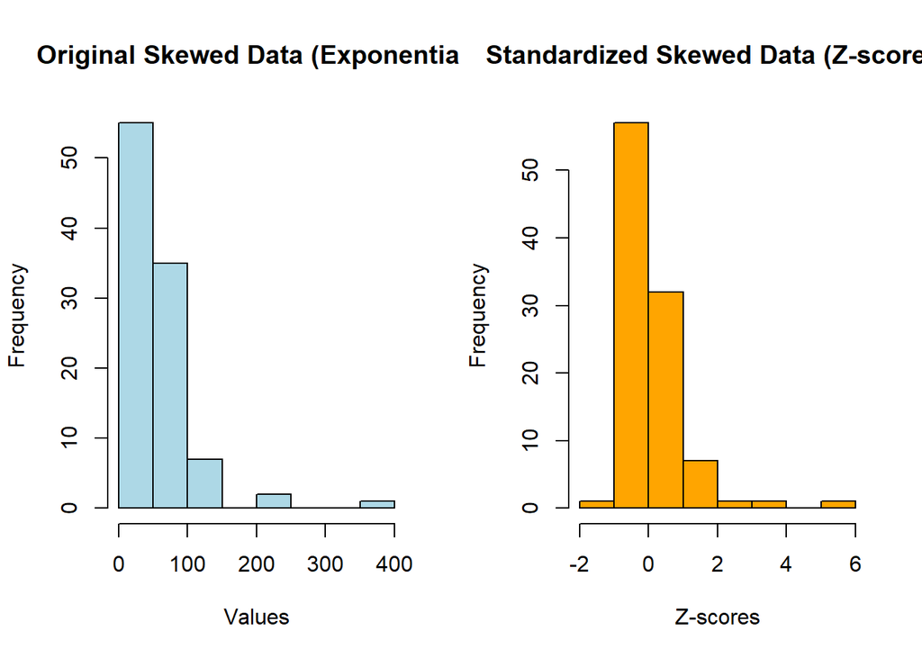

```r
set.seed(123)
skewed_data <- rexp(100, rate = 1/50)  # Right-skewed distribution
z_scores_skewed <- scale(skewed_data)

par(mfrow = c(1, 2))

# Original skewed data
hist(skewed_data, col = 'lightblue', main = 'Original Skewed Data (Exponential)',
     xlab = 'Values')

# Standardized skewed data
hist(z_scores_skewed, col = 'orange', main = 'Standardized Skewed Data (Z-scores)',
     xlab = 'Z-scores')
```

```r
par(mfrow = c(1, 1))
```

# 5. Normal Q-Q Plot

QQ-plots help assess if data follows a normal distribution.

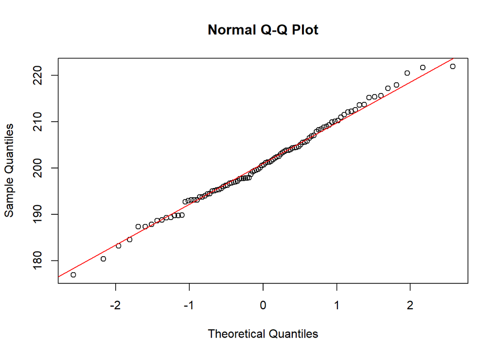

```r
qqnorm(nba_heights)
qqline(nba_heights, col = "red")
```

If points on the Q-Q plot fall close to the diagonal line, the sample is likely from a normal distribution. Deviations from the line indicate departures from normality, such as skewness or outliers.

# 6. Sampling Distribution Example (Basketball Points)

Let’s model the points scored by a basketball player per game, which often exhibits right-skewness due to occasional high-scoring performances. We’ll take multiple samples of game scores to illustrate the Central Limit Theorem - the idea that the distribution of sample means tends toward normality even if the original data is skewed.

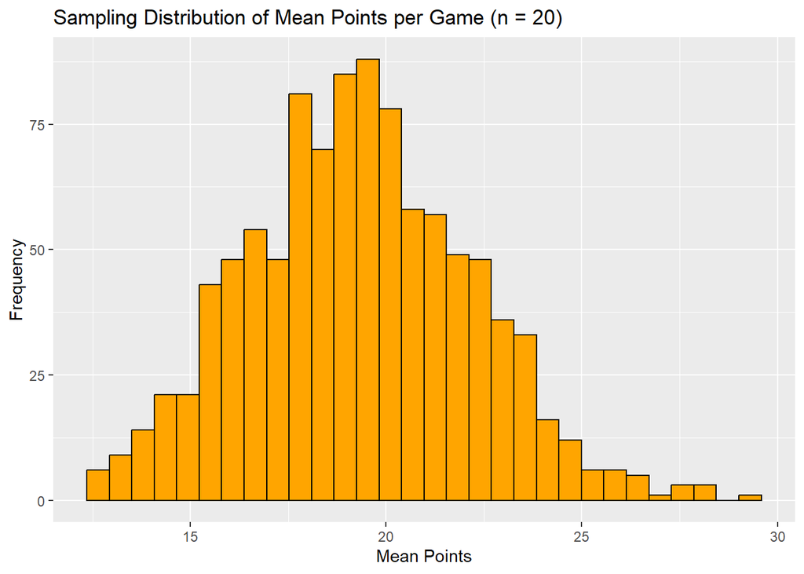

```r
set.seed(42)
# Simulate 1000 game scores: typical basketball scoring with occasional outliers
game_points <- rgamma(1000, shape = 2, scale = 10)

# Generate sampling distribution of means from samples of 20 games each
sample_means <- replicate(1000, mean(sample(game_points, 20)))

# Plot the histogram of sample means
ggplot(data.frame(sample_means), aes(x = sample_means)) +
  geom_histogram(bins = 30, fill = "orange", color = "black") +
  ggtitle("Sampling Distribution of Mean Points per Game (n = 20)") +
  xlab("Mean Points") + ylab("Frequency")
```

## Practical Task: Understanding Normality and Sampling Distributions Using Baseball Data

### Objective

Use real-world baseball batting statistics to:

1. Compute and explore batting averages
2. Standardize data using z-scores
3. Assess normality visually using histograms and Q-Q plots
4. Demonstrate the Central Limit Theorem by simulating the sampling distribution of the mean

### Dataset

- **R users**: `Batting` table from the `Lahman` package
- **Python users**: Batting data from the `pybaseball` package (`batting_stats(2022)`)

### Instructions for R Users

Tools: `Lahman`, `dplyr`, `ggplot2`

1. Install and load the `Lahman` package and retrieve 2022 season stats.
2. Filter players with at least 100 at-bats.
3. Compute batting average:(Hits/At_Bat) `avg = H / AB`.
4. Standardize batting average into z-scores.
5. Plot a histogram of z-scores.
6. Create a Q-Q plot to assess normality.
7. Generate the sampling distribution of the sample mean from 1,000 samples of size 30.
8. Plot the sampling distribution histogram.

### Instructions for Python Users

Tools: `pybaseball`, `pandas`, `matplotlib`, `seaborn`, `scipy.stats`

1. Install `pybaseball` and retrieve 2022 season stats using `batting_stats(2022)`.
2. Filter players with at least 100 at-bats.
3. Compute batting average:(Hits/At_Bat) `AVG = H / AB`.
4. Standardize into z-scores: `(AVG - mean) / std`.
5. Plot a histogram of z-scores using `seaborn`.
6. Create a Q-Q plot using `scipy.stats.probplot`.
7. Draw 1,000 samples of size 30 and compute the mean for each.
8. Plot the histogram of sample means to illustrate the Central Limit Theorem.